# Dynamic Survival Regression models via Ordinary Differential Equations. Ipilimumab data

[F. Javier Rubio](https://sites.google.com/site/fjavierrubio67/) and J. Andres Christen

19 May, 2025

# Dynamic Survival Regression models

## The Logistic ODE hazard model

$$\begin{cases}
h'(t) = \lambda h(t) \left(1 - \dfrac{h(t)}{\kappa}\right), &
h(0) = h_0\\
H'(t) = h(t), & H(0) = 0.
\end{cases}$$
where $\lambda > 0$ represents the intrinsic growth rate of the hazard function, $\kappa > 0$ represents the upper bound of the hazard function, and $h_0 > 0$ is the value of the hazard function at $t=0$. This ODE has the following analytic solution
$$h(t \mid \lambda, \kappa, h_0) = \frac{\kappa h_0 e^{\lambda t}}{\kappa
+ h_0 (e^{\lambda t} - 1)} .$$

## Dynamic regression model

We consider modelling the regression parameters using transformed linear predictors of the type

$$\lambda_i = \exp( \alpha_0 + \alpha_1
\times \text{trt}_i),$$
and
$$\kappa_i
= \exp( \beta_0 + \beta_1 \times \text{trt}_i).$$
We assume the initial conditions $h_0$ to be common to all individuals and unknown.

The following R code analyses a Phase 3 trial of immunotherapy to treat advanced prostate cancer (NCT00861614). We model the parameters $\lambda$ and $\kappa$ using a transformed linear predictor, both containing an intercept and a binary variable indicating the use of `treatment` (Ipilimumab) or `placebo`. See Kwon et al. (2014) and Plana et al. (2022) for more information.

# Data preparation

```r
rm(list=ls())

# Required packages
library(deSolve)
library(survival)
library(ggplot2)
library(survminer)
#library(devtools)
#install_github("FJRubio67/HazReg")
library(HazReg)
library(Rtwalk)
library(knitr)
library(splines)
library(mvtnorm)
library("survminer")
library(spBayesSurv)
source("routinesL.R")
```

```r
# Reading data (CA184-043, NCT00861614, ipilimumab immunotherapy trial)
df0 <- read.csv("CA184043_2A.csv", header = TRUE)
head(df0)
```

```
##    Time Event        Arm
## 1 0.255     1 ipilimumab
## 2 0.345     1 ipilimumab
## 3 0.397     1 ipilimumab
## 4 0.422     1 ipilimumab
## 5 0.613     1 ipilimumab
## 6 0.646     1 ipilimumab
```

```r
#--------------------------------------------------------------------------------------------------
#--------------------------------------------------------------------------------------------------
# Data preparation
#--------------------------------------------------------------------------------------------------
#--------------------------------------------------------------------------------------------------


# New data frame: survival time, vital status, trt (ipilimumab)
trt0 <- vector()
trt0 <- ifelse(as.factor(df0$Arm) == "ipilimumab", 1 , 0)

df <- data.frame(time = df0$Time, status = df0$Event, trt = trt0)
df <- df[order(df$time),]

dim(df)
```

```
## [1] 799   3
```

```r
head(df)
```

```
##      time status trt
## 1   0.255      1   1
## 696 0.267      0   0
## 697 0.267      0   0
## 2   0.345      1   1
## 3   0.397      1   1
## 4   0.422      1   1
```

```r
# Required quantities
status <- as.logical(df$status)
survLTimes <- df$time
```

# Likelihood-based analysis

## Logistic ODE regression model

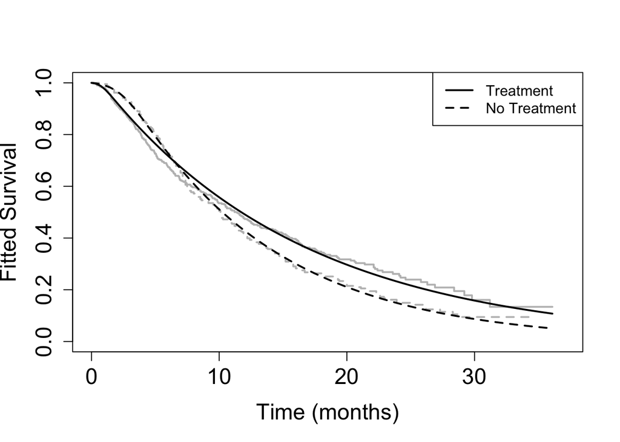

```r
#==================================================================================================
#==================================================================================================
# Maximum Likelihood Regression Analysis
#==================================================================================================
#==================================================================================================

#--------------------------------------------------------------------------------------------------
# Logistic ODE regression model for the hazard function
#--------------------------------------------------------------------------------------------------

# Initial point
initr <- c(0,0,0,0,log(0.01))

# Optimisation step
OPTR <-LODERMLE(init = initr, times = survLTimes, status = status, arm = df$trt, method = "nlminb",
      control = list(iter.max = 1000))

MLER <- OPTR$MLE

# Group 1: : intercept + no treatment
valx_lNT <- c(1,0)
valx_kNT <- c(1,0)

lambdaNT <- exp(valx_lNT%*%MLER[1:2])
kappaNT <- exp(valx_kNT%*%MLER[3:4])
h0 <- MLER[5]

# Fitted hazard and survival: Logistic model
hazLNT <- Vectorize(function(t) hlogisode(t, lambdaNT, kappaNT, h0))
survLNT <- Vectorize(function(t) exp(-chlogisode(t, lambdaNT, kappaNT, h0)))


# Group 2: intercept + treatment
valx_lT <- c(1,1)
valx_kT <- c(1,1)

lambdaT <- exp(valx_lT%*%MLER[1:2])
kappaT <- exp(valx_kT%*%MLER[3:4])

# Fitted hazard and survival: Logistic model
hazLT <- Vectorize(function(t) hlogisode(t, lambdaT, kappaT, h0))
survLT <- Vectorize(function(t) exp(-chlogisode(t, lambdaT, kappaT, h0)))



# Kaplan-Meier estimator
km <- survfit(Surv(time, status) ~ trt, data = df)

plot(km, col = c("gray", "gray"), lty = c(2,1), lwd = 2,
     xlab = "Time (months)", ylab = "Fitted Survival",
     xlim = c(0, 37), ylim = c(0,1), cex.lab = 1.5, cex.axis = 1.5)
# Fitted survival
curve(survLT, 0, max(survLTimes), ylim = c(0.0,1), lwd = 2, xlab = "Time (months)", ylab = "Survival",
      cex.axis = 1.5, cex.lab = 1.5, add = TRUE)
curve(survLNT, 0, max(survLTimes), add=T, lty = 2, lwd = 2)
legend("topright", legend = c("Treatment","No Treatment"), lty = c(1,2), lwd = c(2,2),
       col = c("black","black"))
```

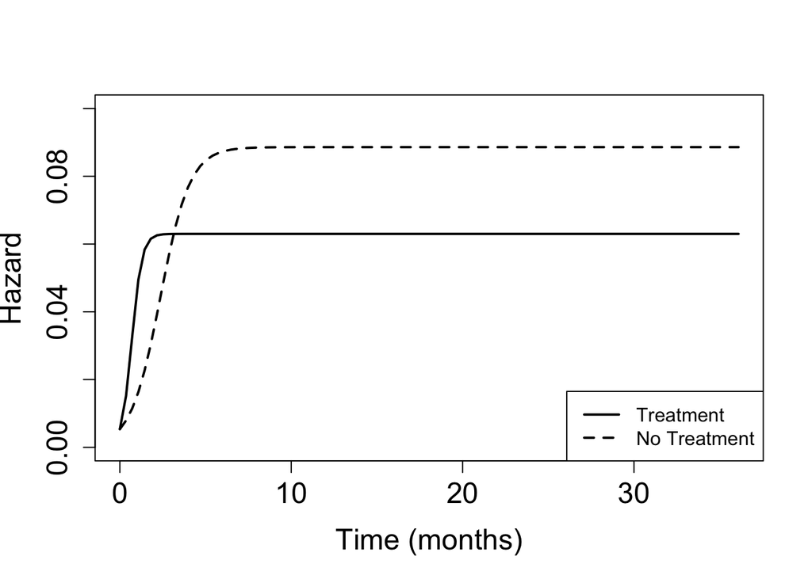

```r
# Fitted hazard
curve(hazLT, 0, max(survLTimes), ylim = c(0, 0.1), lwd = 2, xlab = "Time (months)", ylab = "Hazard",
      cex.axis = 1.5, cex.lab = 1.5)
curve(hazLNT, 0, max(survLTimes), add=T, lty = 2, lwd = 2)
legend("bottomright", legend = c("Treatment","No Treatment"), lty = c(1,2), lwd = c(2,2),
       col = c("black","black"))
```

## 2-Arm Weibull model

```r
#==================================================================================================
#==================================================================================================
# Maximum Likelihood Regression Analysis
#==================================================================================================
#==================================================================================================

#--------------------------------------------------------------------------------------------------
# 2-Arm Weibull model
#--------------------------------------------------------------------------------------------------

# Initial point
initW <- c(0,0,0,0)

# Optimisation step
OPTW <- W2MLE(init = initW, times = survLTimes, status = status, arm = df$trt, method = "nlminb",
              control = list(iter.max = 1000))

MLEW <- OPTW$MLE

# Comparison (Best model: logistic ODE)

c(OPTR$AIC, OPTW$AIC)
```

```
## [1] 4130.011 4163.772
```

```r
c(OPTR$BIC, OPTW$BIC)
```

```
## [1] 4153.428 4182.505
```

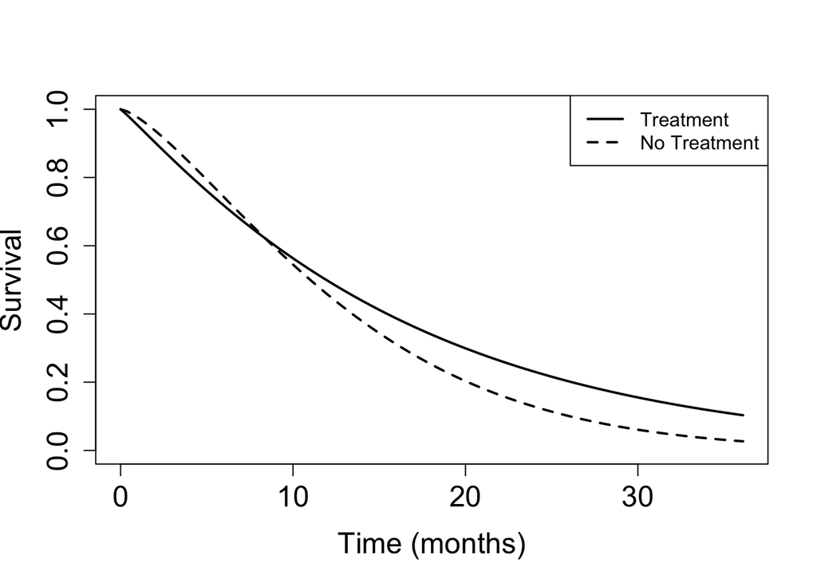

```r
# Group 1: : intercept + no treatment
hazWNT <- Vectorize(function(t) hweibull(t, MLEW[1], MLEW[2]))
survWNT <- Vectorize(function(t) exp(-chweibull(t, MLEW[1], MLEW[2])))


# Group 2: intercept + treatment
hazWT <- Vectorize(function(t) hweibull(t, MLEW[3], MLEW[4]))
survWT <- Vectorize(function(t) exp(-chweibull(t, MLEW[3], MLEW[4])))

# Fitted survival
curve(survWT, 0, max(survLTimes), ylim = c(0.0,1), lwd = 2, xlab = "Time (months)", ylab = "Survival",
      cex.axis = 1.5, cex.lab = 1.5)
curve(survWNT, 0, max(survLTimes), add=T, lty = 2, lwd = 2)
legend("topright", legend = c("Treatment","No Treatment"), lty = c(1,2), lwd = c(2,2),
       col = c("black","black"))
```

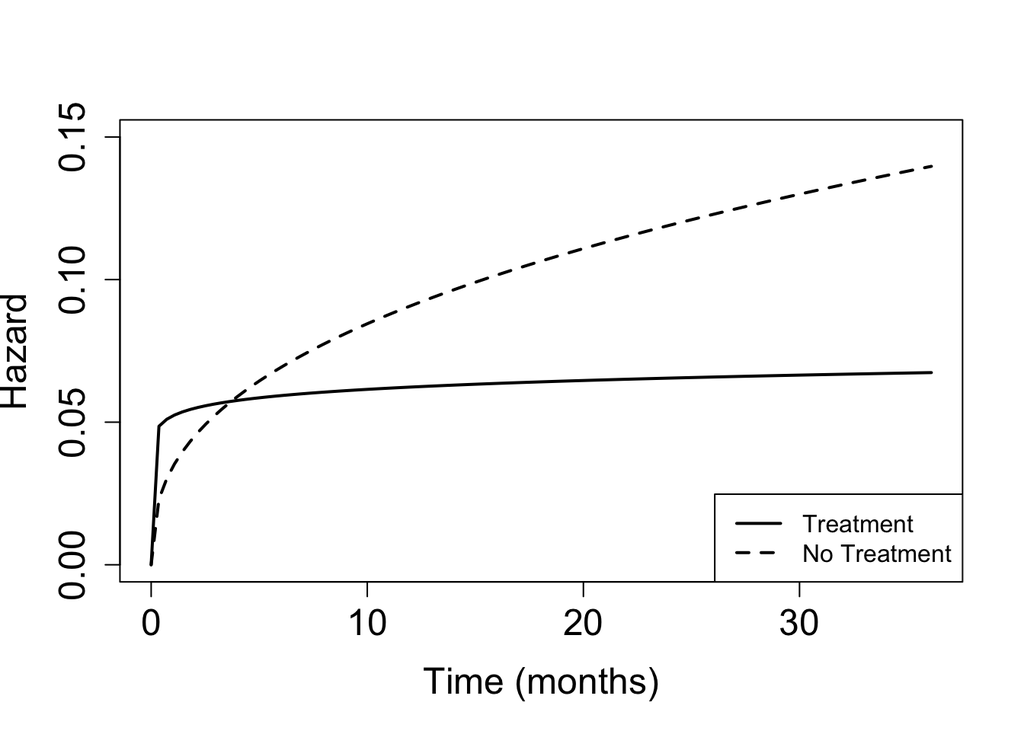

```r
# Fitted hazard
curve(hazWT, 0, max(survLTimes), ylim = c(0, 0.15), lwd = 2, xlab = "Time (months)", ylab = "Hazard",
      cex.axis = 1.5, cex.lab = 1.5)
curve(hazWNT, 0, max(survLTimes), add=T, lty = 2, lwd = 2)
legend("bottomright", legend = c("Treatment","No Treatment"), lty = c(1,2), lwd = c(2,2),
       col = c("black","black"))
```

# Bayesian Analysis: Logistic ODE

```r
#==================================================================================================
#==================================================================================================
# Bayesian Analysis
#==================================================================================================
#==================================================================================================

# Design matrices for the regression models for each parameter
# lambda: intercept + treatment
des_l <- as.matrix(cbind(1,df$trt))
# kappa: intercept + treatment
des_k <- as.matrix(cbind(1,df$trt))


# Required quantities
p_l <- ncol(des_l)
p_k <- ncol(des_k)
statusr <- as.logical(df$status)
t_obsr <- df$time[status]
survtimesr <- df$time
nobs <- sum(status)
n <- nrow(df)


#--------------------------------------------------------------------------------------------------
# Logistic ODE regression model for the hazard function: Analytic solution
#--------------------------------------------------------------------------------------------------

# Support
Support <- function(x) {  TRUE }

# Random initial points
X0R <- function(x) { OPTR$OPT$par + runif(length(OPTR$OPT$par),-0.1,0.1) }

# twalk for analytic solution
set.seed(123)
infor <- Runtwalk( dim=length(OPTR$OPT$par),  Tr=55000,  Obj=log_postreg2, Supp=Support, x0=X0R(), xp0=X0R(),
                   PlotLogPost = FALSE)
```

```
## This is the twalk for R.
## Evaluating the objective density at initial values.
## Opening 12 X 55001 matrix to save output.  Sampling (no graphics mode).
```

```r
# Posterior sample after burn-in and thinning
ind=seq(5000,55000,50)

# Summaries
summr <- apply(infor$output[ind,],2,summary)
colnames(summr) <- c("alpha0","alpha1","beta0","beta1","h_0")
kable(summr, digits = 3)
```

|  | alpha0 | alpha1 | beta0 | beta1 | h_0 |
| --- | --- | --- | --- | --- | --- |
| Min. | -1.203 | 0.184 | -2.676 | -0.695 | -7.222 |
| 1st Qu. | -0.041 | 0.926 | -2.481 | -0.410 | -5.380 |
| Median | 0.108 | 1.166 | -2.429 | -0.347 | -5.079 |
| Mean | 0.127 | 1.255 | -2.428 | -0.349 | -5.128 |
| 3rd Qu. | 0.293 | 1.454 | -2.378 | -0.283 | -4.810 |
| Max. | 1.196 | 5.604 | -2.132 | -0.064 | -3.360 |

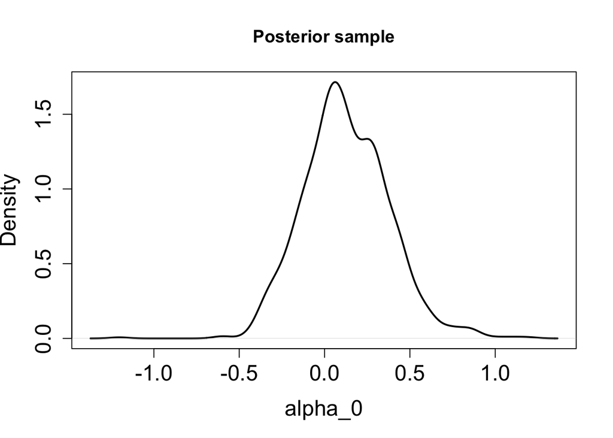

```r
# KDEs
alphap0 <- infor$output[,1][ind]
alphap1 <- infor$output[,2][ind]
betap0 <- infor$output[,3][ind]
betap1 <- infor$output[,4][ind]
h0p <- exp(infor$output[,5][ind])

plot(density(alphap0), main = "Posterior sample", xlab = "alpha_0", ylab = "Density",
     cex.axis = 1.5, cex.lab = 1.5, lwd = 2)
```

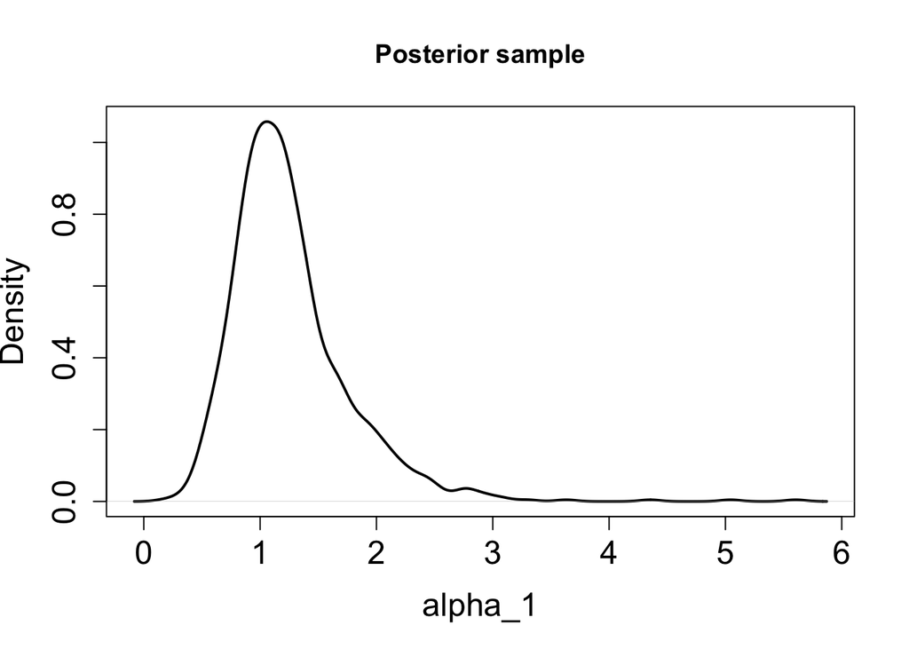

```r
plot(density(alphap1), main = "Posterior sample", xlab = "alpha_1", ylab = "Density",
     cex.axis = 1.5, cex.lab = 1.5, lwd = 2)
```

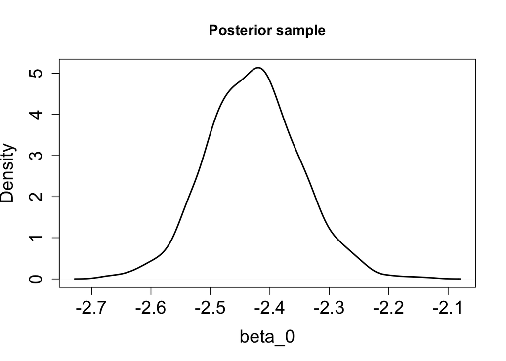

```r
plot(density(betap0), main = "Posterior sample", xlab = "beta_0", ylab = "Density",
     cex.axis = 1.5, cex.lab = 1.5, lwd = 2)
```

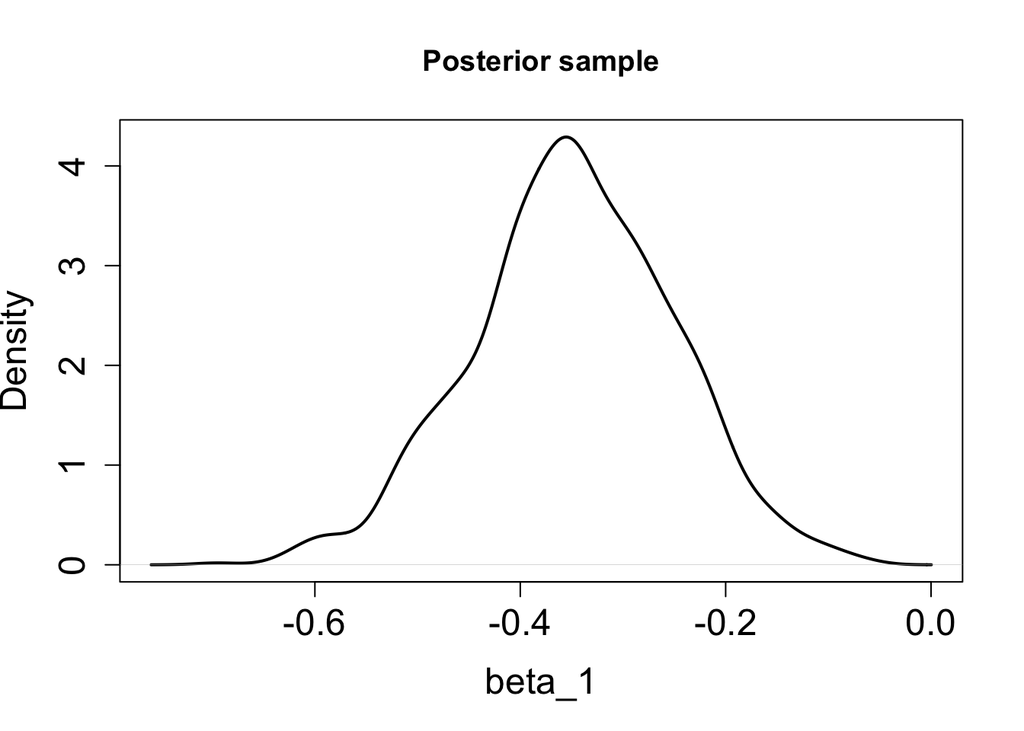

```r
plot(density(betap1), main = "Posterior sample", xlab = "beta_1", ylab = "Density",
     cex.axis = 1.5, cex.lab = 1.5, lwd = 2)
```

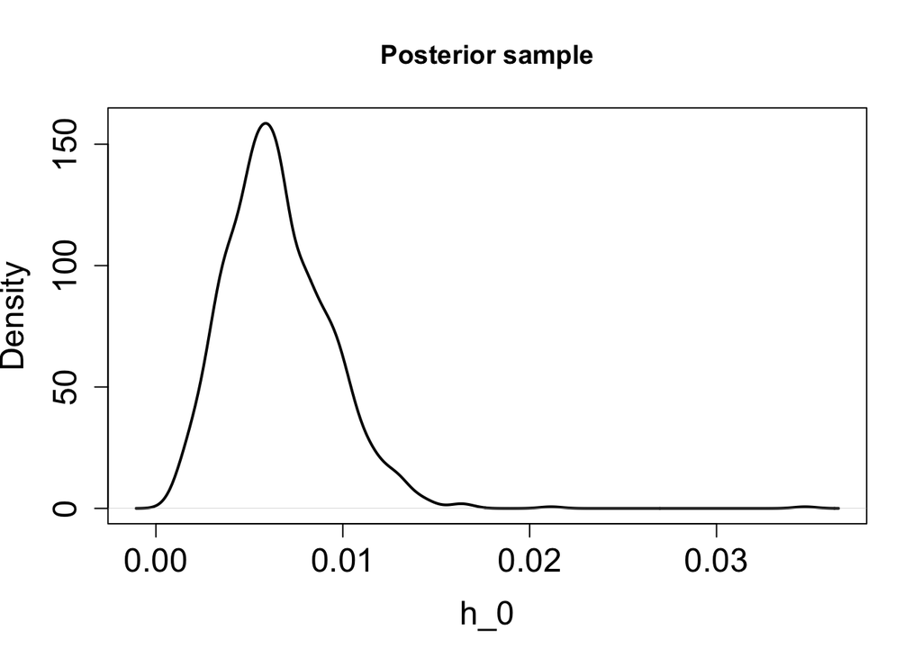

```r
plot(density(h0p), main = "Posterior sample", xlab = "h_0", ylab = "Density",
     cex.axis = 1.5, cex.lab = 1.5, lwd = 2)
```

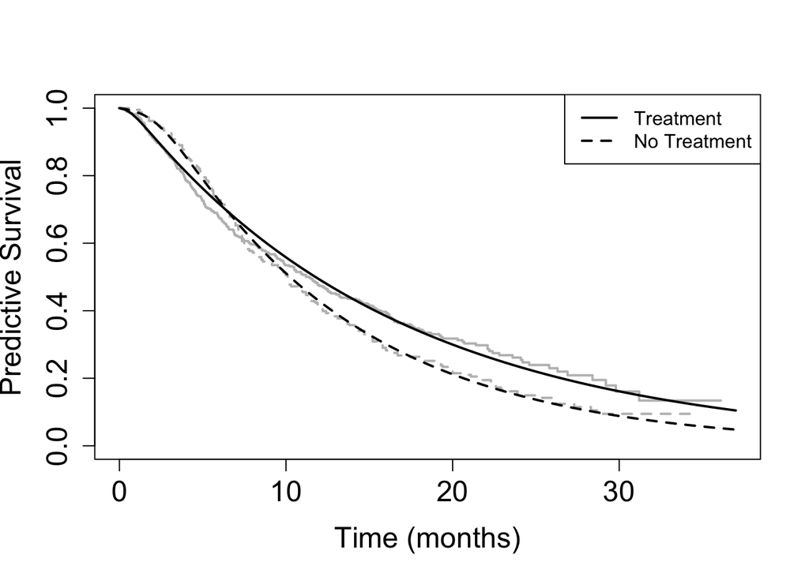

```r
#--------------------------------------------------------------------------------------------------
# Predictive logistic survival: Analytic solution
#--------------------------------------------------------------------------------------------------

acoefs <- cbind(alphap0,alphap1)
bcoefs <- cbind(betap0,betap1)

# Predictive logistic survival: Treatment

predsLT <- Vectorize(function(t){
  out <- vector()
  for(i in 1:length(ind)){
    lambda <- as.numeric(exp(valx_lT%*%acoefs[i,]))
    kappa <- as.numeric(exp(valx_kT%*%bcoefs[i,]))
    out[i] <- exp(-chlogisode( t,lambda, kappa, h0p[i]) )
  }
  return(mean(out))
})


# Predictive logistic survival: No Treatment

predsLNT <- Vectorize(function(t){
  out <- vector()
  for(i in 1:length(ind)){
    lambda <- as.numeric(exp(valx_lNT%*%acoefs[i,]))
    kappa <- as.numeric(exp(valx_kNT%*%bcoefs[i,]))
    out[i] <- exp(-chlogisode( t,lambda, kappa, h0p[i]) )
  }
  return(mean(out))
})


# Comparison
plot(km, col = c("gray", "gray"), lty = c(2,1), lwd = 2,
     xlab = "Time (months)", ylab = "Predictive Survival",
     xlim = c(0, 37), ylim = c(0,1), cex.lab = 1.5, cex.axis = 1.5)

curve(predsLT, 0, 37, ylim = c(0,1), xlab = "Time (months)", ylab = "Predictive Survival", lwd = 2, lty = 1,
      cex.lab = 1.5, cex.axis = 1.5, add = TRUE)
curve(predsLNT, 0, 37, ylim = c(0,1), lwd = 2, lty = 2, add = TRUE)
legend("topright", legend = c("Treatment","No Treatment"), lty = c(1,2), lwd = c(2,2),
       col = c("black","black"))
```

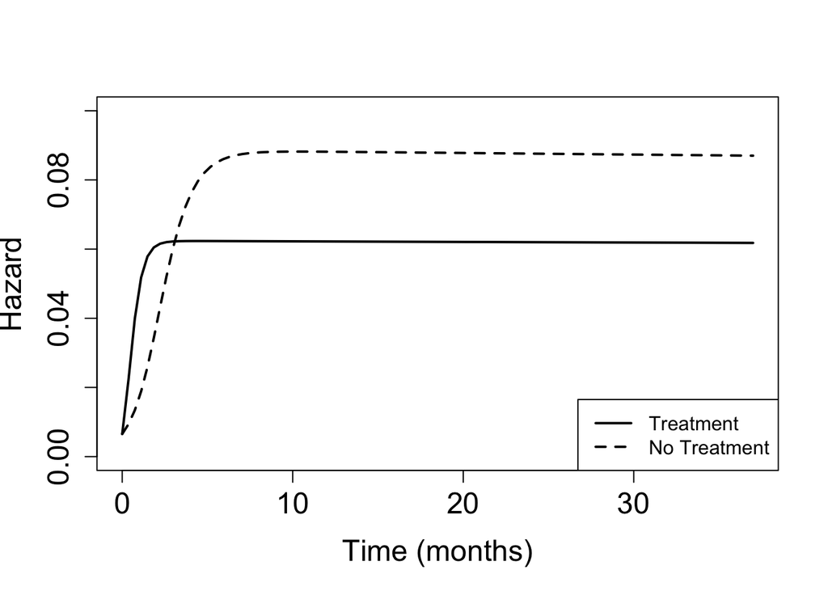

```r
#---------------------------------------------------------------------------------------
# Predictive Hazard functions
#---------------------------------------------------------------------------------------

# Predictive Logistic hazard: Treatment
predhLT <- Vectorize(function(t){
  num <- den <- vector()
  for(i in 1:length(ind)){
    lambda <- as.numeric(exp(valx_lT%*%acoefs[i,]))
    kappa <- as.numeric(exp(valx_kT%*%bcoefs[i,]))
    num[i] <- exp(-chlogisode( t, lambda, kappa, h0p[i]))*hlogisode( t, lambda, kappa, h0p[i])
    den[i] <- exp(-chlogisode( t, lambda, kappa, h0p[i]))
  }
  return(mean(num)/mean(den))
})

# Predictive Logistic hazard: No Treatment
predhLNT <- Vectorize(function(t){
  num <- den <- vector()
  for(i in 1:length(ind)){
    lambda <- as.numeric(exp(valx_lNT%*%acoefs[i,]))
    kappa <- as.numeric(exp(valx_kNT%*%bcoefs[i,]))
    num[i] <- exp(-chlogisode( t, lambda, kappa, h0p[i]))*hlogisode( t, lambda, kappa, h0p[i])
    den[i] <- exp(-chlogisode( t, lambda, kappa, h0p[i]))
  }
  return(mean(num)/mean(den))
})



# Logistic
curve(predhLT, 0, 37, ylim = c(0, 0.1), lwd = 2, xlab = "Time (months)", ylab = "Hazard",
      cex.axis = 1.5, cex.lab = 1.5)
curve(predhLNT, 0, 37, add=T, lty = 2, lwd = 2)
legend("bottomright", legend = c("Treatment","No Treatment"), lty = c(1,2), lwd = c(2,2),
       col = c("black","black"))
```

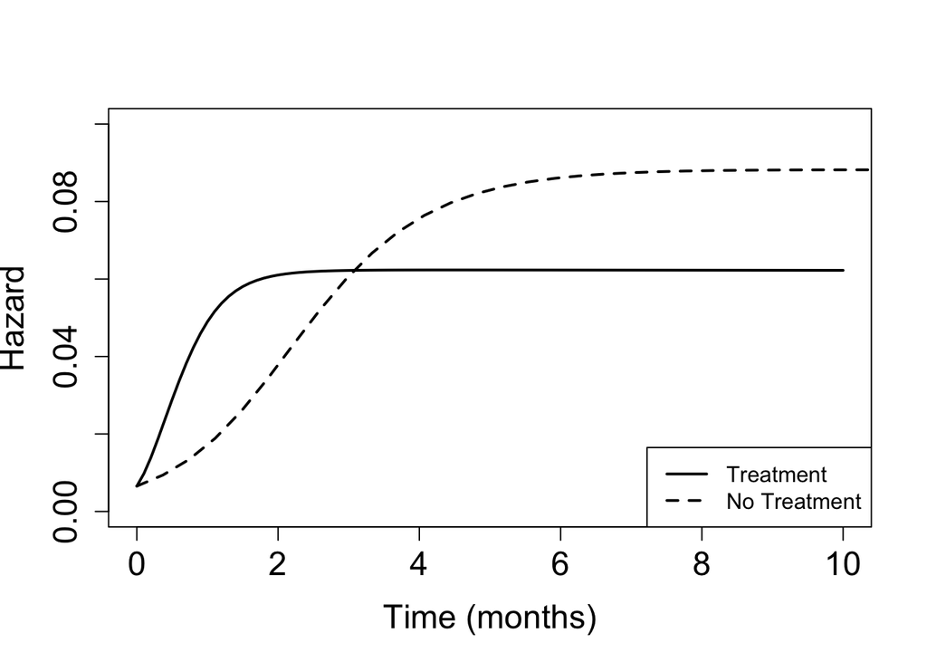

```r
# Zoom in
curve(predhLT, 0, 10, ylim = c(0, 0.1), lwd = 2, xlab = "Time (months)", ylab = "Hazard",
      cex.axis = 1.5, cex.lab = 1.5)
curve(predhLNT, 0, 37, add=T, lty = 2, lwd = 2)
legend("bottomright", legend = c("Treatment","No Treatment"), lty = c(1,2), lwd = c(2,2),
       col = c("black","black"))
```

## Credible intervals: full range

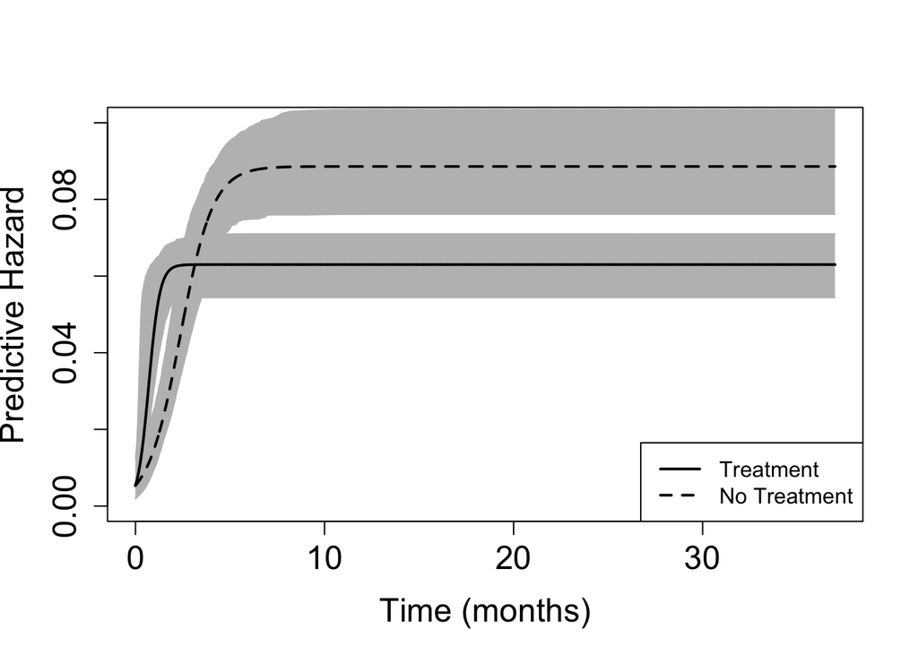

```r
# Creating the credible envelopes
tvec <- seq(0,37,by = 0.01)
ntvec <- length(tvec)

hCINT <- matrix(0, ncol = ntvec, nrow = length(ind))
hCIT <- matrix(0, ncol = ntvec, nrow = length(ind))
sCINT <- matrix(0, ncol = ntvec, nrow = length(ind))
sCIT <- matrix(0, ncol = ntvec, nrow = length(ind))

for(j in 1:length(ind)){
  for(k in 1:ntvec){
    lambda <- as.numeric(exp(valx_lNT%*%acoefs[j,]))
    kappa <- as.numeric(exp(valx_kNT%*%bcoefs[j,]))
    hCINT[j,k ] <- hlogisode( tvec[k],lambda, kappa, h0p[j])
    sCINT[j,k ] <- exp(-chlogisode( tvec[k],lambda, kappa, h0p[j]))
  }
  for(k in 1:ntvec){
    lambda <- as.numeric(exp(valx_lT%*%acoefs[j,]))
    kappa <- as.numeric(exp(valx_kT%*%bcoefs[j,]))
    hCIT[j,k ] <- hlogisode( tvec[k],lambda, kappa, h0p[j])
    sCIT[j,k ] <- exp(-chlogisode( tvec[k],lambda, kappa, h0p[j]))
  }
}

hT <-  hazLT(tvec)
hNT <- hazLNT(tvec)

hCITL <- apply(hCIT, 2, ql)
hCINTL <- apply(hCINT, 2, ql)
hCITU <- apply(hCIT, 2, qu)
hCINTU <- apply(hCINT, 2, qu)


sT <-  survLT(tvec)
sNT <- survLNT(tvec)

sCITL <- apply(sCIT, 2, ql)
sCINTL <- apply(sCINT, 2, ql)
sCITU <- apply(sCIT, 2, qu)
sCINTU <- apply(sCINT, 2, qu)

# Plots

plot(tvec,  hT, type = "l", ylim = c(0, 0.1), xlab = "Time (months)", ylab = "Predictive Hazard",
       cex.axis = 1.5, cex.lab = 1.5, lwd = 2, lty = 1)
points(tvec,  hNT, col = "black", type = "l", lwd = 2, lty = 2)
points(tvec,  hCITL, col = "gray", type = "l")
points(tvec,  hCITU, col = "gray", type = "l")
points(tvec,  hCINTL, col = "gray", type = "l")
points(tvec,  hCINTU, col = "gray", type = "l")
polygon(c(tvec, rev(tvec)), c(hCITL[order(tvec)], rev(hCITU[order(tvec)])),
        col = "gray", border = NA)
polygon(c(tvec, rev(tvec)), c(hCINTL[order(tvec)], rev(hCINTU[order(tvec)])),
        col = "gray", border = NA)
points(tvec,  hT, type = "l", col = "black", lwd = 2, lty =1)
points(tvec,  hNT, col = "black", type = "l", lwd = 2, lty = 2)
legend("bottomright", legend = c("Treatment", "No Treatment"), lty = c(1,2),
       lwd = c(2,2), col = c("black","black"))
```

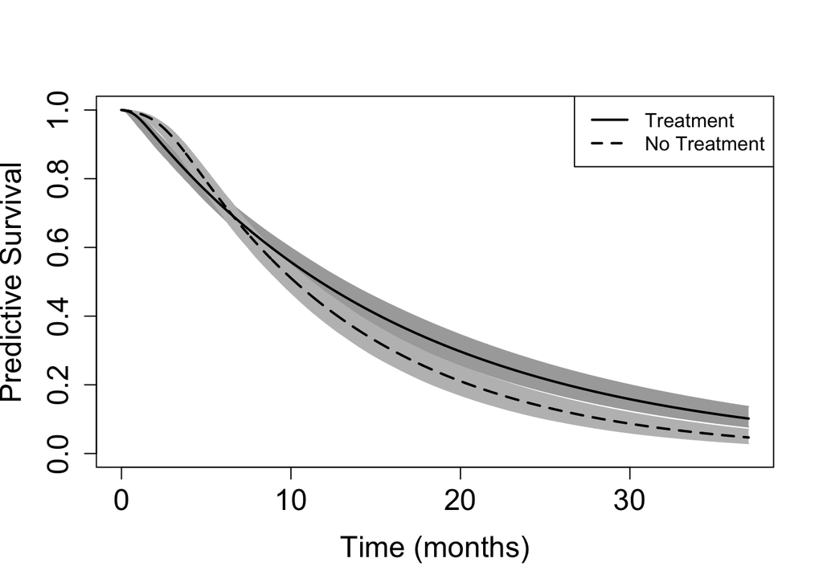

```r
plot(tvec,  sT, type = "l", ylim = c(0,1), xlab = "Time (months)", ylab = "Predictive Survival",
     cex.axis = 1.5, cex.lab = 1.5, lwd = 2, lty = 1)
points(tvec,  sNT, col = "black", type = "l", lwd = 2, lty = 2)
points(tvec,  sCITL, col = "darkgray", type = "l")
points(tvec,  sCITU, col = "darkgray", type = "l")
points(tvec,  sCINTL, col = "gray", type = "l")
points(tvec,  sCINTU, col = "gray", type = "l")
polygon(c(tvec, rev(tvec)), c(sCITL[order(tvec)], rev(sCITU[order(tvec)])),
        col = "darkgray", border = NA)
polygon(c(tvec, rev(tvec)), c(sCINTL[order(tvec)], rev(sCINTU[order(tvec)])),
        col = "gray", border = NA)
points(tvec,  sT, type = "l", col = "black", lwd = 2, lty =1)
points(tvec,  sNT, col = "black", type = "l", lwd = 2, lty = 2)
legend("topright", legend = c("Treatment", "No Treatment"), lty = c(1,2),
       lwd = c(2,2), col = c("black","black"))
```

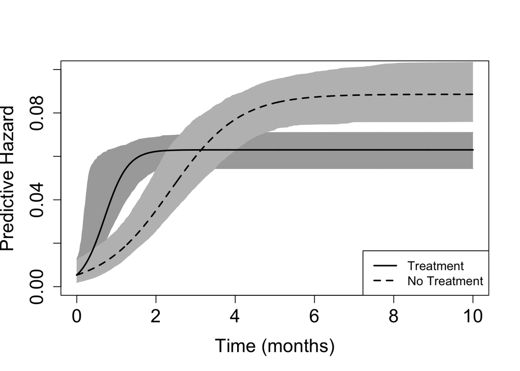

```r
# Creating the credible envelopes
tvec <- seq(0,10,by = 0.01)
ntvec <- length(tvec)

hCINT <- matrix(0, ncol = ntvec, nrow = length(ind))
hCIT <- matrix(0, ncol = ntvec, nrow = length(ind))
sCINT <- matrix(0, ncol = ntvec, nrow = length(ind))
sCIT <- matrix(0, ncol = ntvec, nrow = length(ind))

for(j in 1:length(ind)){
  for(k in 1:ntvec){
    lambda <- as.numeric(exp(valx_lNT%*%acoefs[j,]))
    kappa <- as.numeric(exp(valx_kNT%*%bcoefs[j,]))
    hCINT[j,k ] <- hlogisode( tvec[k],lambda, kappa, h0p[j])
    sCINT[j,k ] <- exp(-chlogisode( tvec[k],lambda, kappa, h0p[j]))
  }
  for(k in 1:ntvec){
    lambda <- as.numeric(exp(valx_lT%*%acoefs[j,]))
    kappa <- as.numeric(exp(valx_kT%*%bcoefs[j,]))
    hCIT[j,k ] <- hlogisode( tvec[k],lambda, kappa, h0p[j])
    sCIT[j,k ] <- exp(-chlogisode( tvec[k],lambda, kappa, h0p[j]))
  }
}

hT <-  hazLT(tvec)
hNT <- hazLNT(tvec)

hCITL <- apply(hCIT, 2, ql)
hCINTL <- apply(hCINT, 2, ql)
hCITU <- apply(hCIT, 2, qu)
hCINTU <- apply(hCINT, 2, qu)


sT <-  survLT(tvec)
sNT <- survLNT(tvec)

sCITL <- apply(sCIT, 2, ql)
sCINTL <- apply(sCINT, 2, ql)
sCITU <- apply(sCIT, 2, qu)
sCINTU <- apply(sCINT, 2, qu)

# Plots

plot(tvec,  hT, type = "l", ylim = c(0, 0.1), xlab = "Time (months)", ylab = "Predictive Hazard",
       cex.axis = 1.5, cex.lab = 1.5, lwd = 2, lty = 1)
points(tvec,  hNT, col = "black", type = "l", lwd = 2, lty = 2)
points(tvec,  hCITL, col = "darkgray", type = "l")
points(tvec,  hCITU, col = "darkgray", type = "l")
points(tvec,  hCINTL, col = "gray", type = "l")
points(tvec,  hCINTU, col = "gray", type = "l")
polygon(c(tvec, rev(tvec)), c(hCITL[order(tvec)], rev(hCITU[order(tvec)])),
        col = "darkgray", border = NA)
polygon(c(tvec, rev(tvec)), c(hCINTL[order(tvec)], rev(hCINTU[order(tvec)])),
        col = "gray", border = NA)
points(tvec,  hT, type = "l", col = "black", lwd = 2, lty =1)
points(tvec,  hNT, col = "black", type = "l", lwd = 2, lty = 2)
legend("bottomright", legend = c("Treatment", "No Treatment"), lty = c(1,2),
       lwd = c(2,2), col = c("black","black"))
```

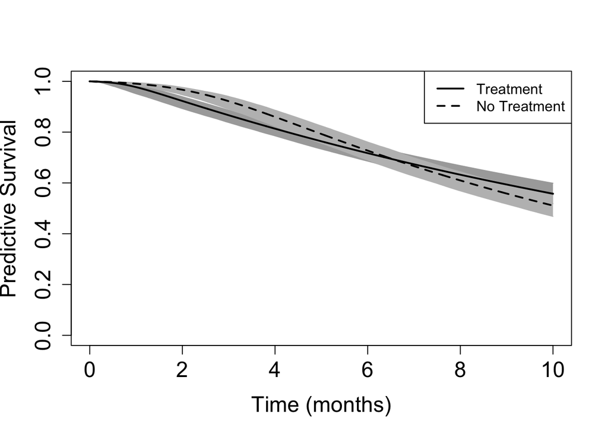

```r
plot(tvec,  sT, type = "l", ylim = c(0,1), xlab = "Time (months)", ylab = "Predictive Survival",
     cex.axis = 1.5, cex.lab = 1.5, lwd = 2, lty = 1)
points(tvec,  sNT, col = "black", type = "l", lwd = 2, lty = 2)
points(tvec,  sCITL, col = "darkgray", type = "l")
points(tvec,  sCITU, col = "darkgray", type = "l")
points(tvec,  sCINTL, col = "gray", type = "l")
points(tvec,  sCINTU, col = "gray", type = "l")
polygon(c(tvec, rev(tvec)), c(sCITL[order(tvec)], rev(sCITU[order(tvec)])),
        col = "darkgray", border = NA)
polygon(c(tvec, rev(tvec)), c(sCINTL[order(tvec)], rev(sCINTU[order(tvec)])),
        col = "gray", border = NA)
points(tvec,  sT, type = "l", col = "black", lwd = 2, lty =1)
points(tvec,  sNT, col = "black", type = "l", lwd = 2, lty = 2)
legend("topright", legend = c("Treatment", "No Treatment"), lty = c(1,2),
       lwd = c(2,2), col = c("black","black"))
```

Kwon, E. D., C. G. Drake, H. I. Scher, K. Fizazi, A. Bossi, A. J. M. Van den Eertwegh, M. Krainer, N. Houede, R. Santos, and H. Mahammedi. 2014. “Ipilimumab Versus Placebo After Radiotherapy in Patients with Metastatic Castration-Resistant Prostate Cancer That Had Progressed After Docetaxel Chemotherapy (CA184-043): A Multicentre, Randomised, Double-Blind, Phase 3 Trial.” *The Lancet Oncology* 15 (7): 700–712.

Plana, D., G. Fell, B. M. Alexander, A. C. Palmer, and P. K. Sorger. 2022. “Cancer Patient Survival Can Be Parametrized to Improve Trial Precision and Reveal Time-Dependent Therapeutic Effects.” *Nature Communications* 13 (1): 873.